# Flexible Damage Functions

Author

James Rising, Sebastian Cadavid Sanchez, Climate Impact Lab

Published

April 30, 2026

## 0.1 Mortality: Allcause

Flexible damage function parameters at the Impact Region level.

**Change in all-cause all-age mortality rate (deaths per 100,000) under full adaptation with adaptation costs**

**Outcome units:** `physical`

$$D_{it} = (\alpha_i T_t + \beta_i T_t^2) \cdot Y_{it}^{\gamma}$$

where $\gamma$ is the income elasticity (fitted globally), $\alpha_i$ is the linear coefficient, and $\beta_i$ is the quadratic coefficient.

# 1 Global Estimation

## 1.1 Income Elasticity Estimation

The income elasticity $\gamma$ is estimated using a fixed-effects regression:

$$y_{it} = \gamma \cdot \log(Y_{it}) + \mu_{g(i,T)} + \nu_t + \varepsilon_{it}$$

where $\mu_{g(i,T)}$ are region-by-temperature-bin fixed effects and $\nu_t$ are year fixed effects.

Table 1: Income Elasticity (Gamma) Estimation Results

| Statistic | Value |
| --- | --- |
| Income elasticity ($\gamma$) | -0.0001 |
| Standard error | 9.32e-06 |
| 95% CI | [-0.0002, -0.0001] |
| R-squared | 0.8995 |
| Observations | 29,118,222 |
| Regions | 24,326 |
| Gamma quantiles | 19 |

# 2 Parameter Distributions

## 2.1 8-Panel Summary

Row 1: gamma, alpha, beta, rsqr1. Row 2: rho, zeta, eta, rsqr2.

```
Using median gamma: -0.000145, 462,194 rows (of 462,194 total)
```

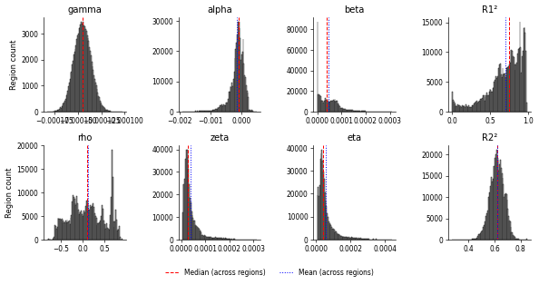

Figure 1: Distribution of Regional Parameters

## 2.2 Projection Equation and Parameter Definitions

The estimated parameters are used to project damages via Monte Carlo sampling:

$$D_{it}^k = (\hat{\alpha}_{ik} T_t + \hat{\beta}_{ik} T_t^2) Y_{it}^{\hat{\gamma}_k} + \hat{\theta}_{ik} T_t Y_{it}^{\hat{\gamma}_k} + \hat{\phi}_{it}^k$$

where $k$ indexes the Monte Carlo draw. The parameters in each row of the output CSV control distinct components of this equation:

- **gamma**: income elasticity $\hat{\gamma}_k$, one of 19 quantile values drawn from $N(\hat{\gamma}, SE(\hat{\gamma}))$
- **alpha, beta**: linear and quadratic temperature coefficients; $\hat{\alpha}_{ik}$ and $\hat{\beta}_{ik}$ are drawn from the joint normal defined by the VCV below
- **sigma11, sigma12, sigma22**: variance-covariance matrix of $(\alpha, \beta)$, used for joint uncertainty sampling
- **rho**: correlation between regional and global polynomial residuals $\rho_i$, used to maintain spatial covariance across regions in Monte Carlo draws
- **zeta**: temperature-dependent error scale $\zeta_{ik}$; the run-specific error term $\hat{\theta}_{ik}$ is drawn from $N(0, \zeta_{ik})$
- **eta**: residual noise standard deviation $\eta_{ik}$; the annual noise $\hat{\phi}_{it}^k$ is drawn from $N(0, \eta_{ik})$
- **rsqr1, rsqr2**: polynomial fit quality and error model fit, respectively

## 2.3 Summary Statistics

Table 2: Regional Parameter Summary

| Parameter | Mean | Median | Std | Min | Max | N |
| --- | --- | --- | --- | --- | --- | --- |
| alpha | -0.0001467 | -0.0001091 | 0.0002406 | -0.001916 | 0.0004954 | 24,326 |
| beta | 4.611e-05 | 3.777e-05 | 4.38e-05 | 0 | 0.0003094 | 24,326 |
| rho | 0.1109 | 0.09693 | 0.3978 | -0.8117 | 0.901 | 24,326 |
| zeta | 3.926e-05 | 2.835e-05 | 3.493e-05 | 4.177e-06 | 0.0003166 | 24,326 |
| eta | 5.812e-05 | 4.213e-05 | 5.21e-05 | 7.532e-06 | 0.0004405 | 24,326 |
| rsqr1 | 0.6929 | 0.7475 | 0.2269 | 8.478e-07 | 0.9811 | 24,326 |
| rsqr2 | 0.6206 | 0.6209 | 0.05553 | 0.2741 | 0.8509 | 24,326 |

# 3 Spaghetti Curves

Regional damage function curves showing D(T) = αT + βT² for sampled regions.

[interactive chart not shown]

Figure 2: Regional Damage Functions

# 4 Zero Crossings

The zero crossing (extremum) of the parabola occurs at $T^* = -\alpha / (2\beta)$.

Table 3: Zero Crossing Statistics

| Category | Count | Percentage |
| --- | --- | --- |
| β = 0 (no crossing) | 3758 | 15.4% |
| T > 20°C (beyond graph) | 312 | 1.3% |
| T < 0°C (negative crossing) | 4717 | 19.4% |
| Valid crossings (0-20°C) | 15539 | 63.9% |

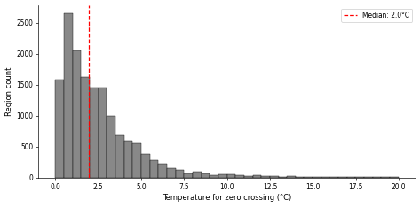

Figure 3: Distribution of Zero Crossing Temperatures

# 5 Slope Analysis

Maximum slope between 0 and 10°C: $\frac{dM}{dT} = \alpha + 2\beta T$

The maximum occurs at either T=0 or T=10 (endpoints of interval).

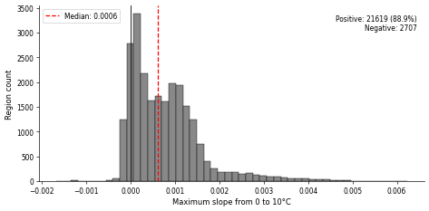

Figure 4: Distribution of Maximum Slopes (0-10°C)

*Convexity analysis omitted (beta constraint active).*

# 6 R-squared Analysis

## 6.1 Polynomial Fit Quality (rsqr1)

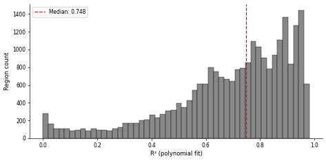

Figure 5: Regional Fit Quality (R-squared)

## 6.2 Error Model R-squared (rsqr2) Quantiles

Table 4: rsqr2 Quantiles

| 0% (Min) | 25% | 50% (Median) | 75% | 100% (Max) |
| --- | --- | --- | --- | --- |
| 0.2741 | 0.5840 | 0.6209 | 0.6586 | 0.8509 |

# 7 Modelled Variance

Modelled variance statistic: $1 - \frac{\sum_i \eta_i^2}{\sum_i D_i^2}$

Table 5: Modelled Variance Statistics

| Statistic | Value |
| --- | --- |
| Modelled variance | 0.9862 |
| Sum(η²) | 0.0001 |
| Sum(D²) at T=3.0°C | 0.0107 |
| N regions | 24,326 |

# 8 Best- and Worst-Fitting Regions

The 3 worst- and 3 best-fitting regions by R-squared, with raw simulation data overlaid on the fitted polynomial curve. **Red rows = worst fits**, **green rows = best fits**.

Table 6: Best- and worst-fitting regions

Top 3 best fit (R²) Top 3 worst fit (R²)

| Region | α | β | η | R² |
| --- | --- | --- | --- | --- |
| CAN.8.119.2375 | -0.00152 | 3.88e-5 | 1.14e-4 | 0.98 |
| CAN.8.119.2371 | -0.00153 | 4.67e-5 | 1.13e-4 | 0.98 |
| CAN.8.117.2350 | -0.00128 | 3.49e-6 | 1.05e-4 | 0.979 |
| IND.34.571.2234 | -1.07e-5 | 1.67e-6 | 5.14e-5 | 0.00173 |
| CHN.6.43.270 | -1.74e-6 | 1.19e-7 | 1.47e-5 | 0.00205 |
| CHL.5.16.90 | -2.45e-5 | 5.54e-6 | 7.10e-5 | 0.00215 |

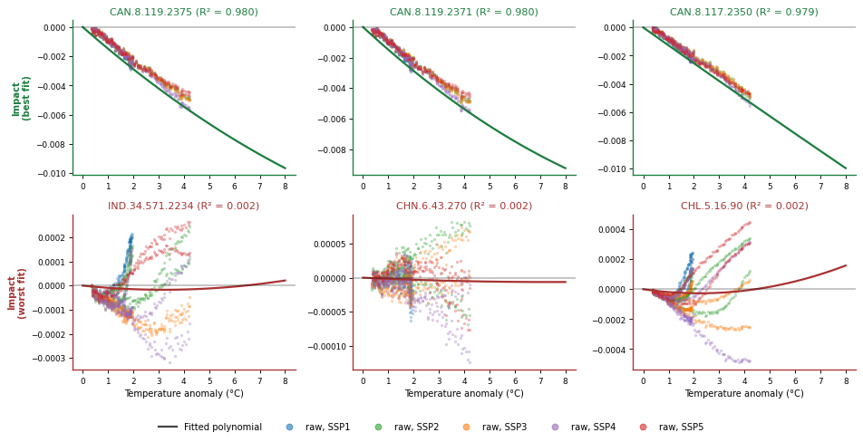

# 9 Regional Parameter Maps

## 9.1 Alpha (Linear Coefficient)

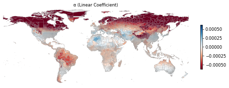

Figure 7: α (linear coefficient)

## 9.2 Beta (Quadratic Coefficient)

Beta ($\beta$) represents the curvature of the damage function.

The convexity ($\beta \geq 0$) constraint is enforced for this sector, meaning damages accelerate with warming (U-shaped response).

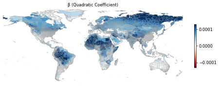

Figure 8: β (quadratic coefficient)

## 9.3 R-squared (Fit Quality)

$R^2$ measures the polynomial fit quality. Higher values indicate that the quadratic form captures more of the variance in the data.

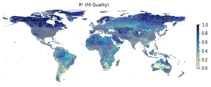

Figure 9: R² (stage 1 fit quality)

# 10 F2: Flex vs Raw Comparison

Comparison of flexible damage function predictions against raw simulation means.

For each scenario (RCP × SSP × Model), we compute at the final year:

- **Flex predicted**: $(\alpha \cdot T + \beta \cdot T^2) \cdot Y^\gamma$
- **Raw actual**: The outcome variable (y) from the source data

**Year 2099**: 390,048 rows

**rcp45**

**SSP1**

**high**

**Correlation:** 0.8921 | **RMSE:** 0.000204 | **Sign agreement:** 80.4%

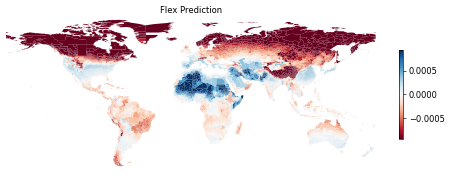

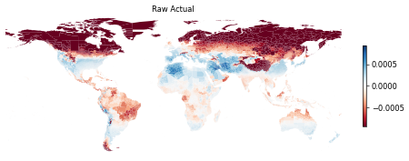

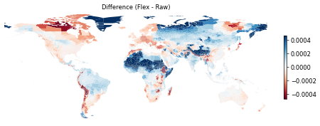

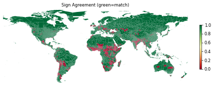

[interactive chart not shown]

Top 5 best predicted Top 5 worst predicted

Year 2099 · T<sub>mean</sub> across these regions: 1.96°C

| Region | Raw | Flex | Residual |
| --- | --- | --- | --- |
| CAN.1.2.R286f00cd4d0da255 | -9.99e-4 | -9.99e-4 | 9.50e-9 |
| VNM.5.45.R58c5fe0daffcaaac | -1.00e-4 | -1.00e-4 | 1.50e-8 |
| CHN.20.222.1484 | -2.75e-4 | -2.75e-4 | -2.99e-8 |
| USA.27.1616 | -4.84e-4 | -4.84e-4 | 3.64e-8 |
| IND.12.143.548 | -3.57e-5 | -3.58e-5 | -3.68e-8 |
| NPL.5.13.67 | -0.00301 | -8.71e-4 | 0.00214 |
| NPL.4.10.50 | -0.00288 | -9.05e-4 | 0.00197 |
| NPL.0.8.61 | -0.00289 | -9.61e-4 | 0.00193 |
| NPL.4.10.51 | -0.00229 | -0.00101 | 0.00128 |
| SDN.6.16.74.R329752b1f48ceaf7 | 1.82e-4 | 0.00143 | 0.00125 |

**low**

**Correlation:** 0.9441 | **RMSE:** 0.000145 | **Sign agreement:** 87.3%

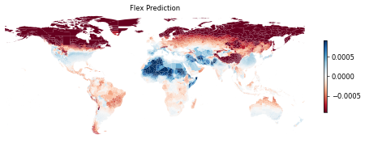

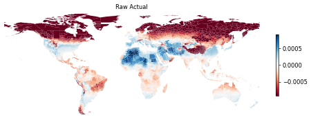

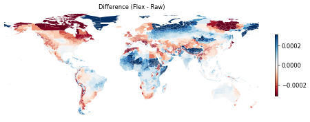

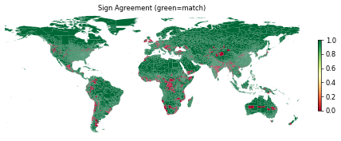

[interactive chart not shown]

Top 5 best predicted Top 5 worst predicted

Year 2099 · T<sub>mean</sub> across these regions: 1.96°C

| Region | Raw | Flex | Residual |
| --- | --- | --- | --- |
| USA.14.620 | 2.70e-4 | 2.70e-4 | 1.42e-9 |
| TUR.30.Rc103134224044484 | -2.54e-4 | -2.54e-4 | 1.89e-9 |
| AUS.11.1258 | 5.79e-5 | 5.79e-5 | -5.30e-9 |
| USA.11.417 | 1.47e-4 | 1.47e-4 | 7.58e-9 |
| THA.69.Rf8a4e129248153ca | -8.65e-5 | -8.65e-5 | -8.75e-9 |
| NPL.5.13.67 | -0.00207 | -8.71e-4 | 0.0012 |
| NPL.4.10.50 | -0.00199 | -9.05e-4 | 0.00109 |
| NPL.0.8.61 | -0.00203 | -9.61e-4 | 0.00107 |
| RUS.65.1730.1847 | -0.00184 | -0.00291 | -0.00107 |
| RUS.65.1756.1873 | -0.00176 | -0.0028 | -0.00105 |

**SSP2**

**high**

**Correlation:** 0.9377 | **RMSE:** 0.000173 | **Sign agreement:** 88.1%

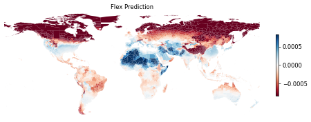

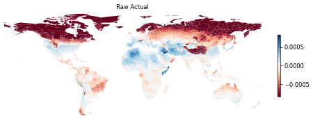

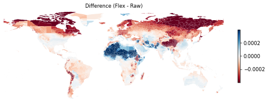

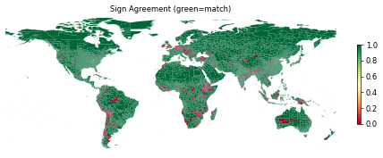

[interactive chart not shown]

Top 5 best predicted Top 5 worst predicted

Year 2099 · T<sub>mean</sub> across these regions: 1.96°C

| Region | Raw | Flex | Residual |
| --- | --- | --- | --- |
| IND.20.278.1052 | -1.62e-5 | -1.61e-5 | 6.58e-9 |
| CHN.6.58.348 | -4.79e-5 | -4.79e-5 | -6.98e-9 |
| USA.36.2088 | 1.04e-4 | 1.04e-4 | 1.04e-8 |
| USA.5.231 | 1.24e-4 | 1.24e-4 | 1.24e-8 |
| CAF.16.48 | -5.39e-5 | -5.39e-5 | 1.48e-8 |
| RUS.65.1730.1847 | -0.00175 | -0.00291 | -0.00116 |
| RUS.65.1746.1863 | -0.0019 | -0.00306 | -0.00115 |
| RUS.65.1756.1873 | -0.00169 | -0.0028 | -0.00111 |
| SDN.6.16.74.R329752b1f48ceaf7 | 3.47e-4 | 0.00143 | 0.00108 |
| SDN.6.15.72.223 | 3.67e-4 | 0.00145 | 0.00108 |

**low**

**Correlation:** 0.9766 | **RMSE:** 0.000136 | **Sign agreement:** 89.8%

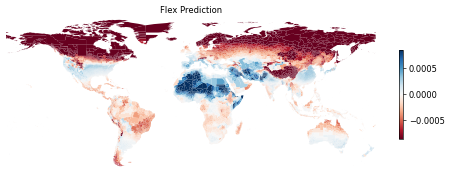

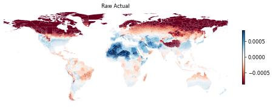

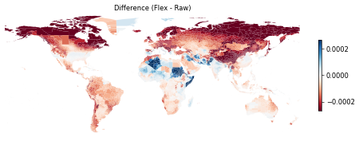

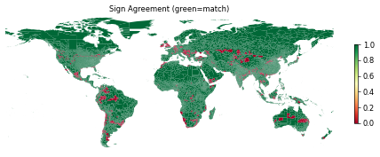

[interactive chart not shown]

Top 5 best predicted Top 5 worst predicted

Year 2099 · T<sub>mean</sub> across these regions: 1.96°C

| Region | Raw | Flex | Residual |
| --- | --- | --- | --- |
| AUS.4.301 | 8.22e-5 | 8.22e-5 | -3.81e-9 |
| IND.31.462.1856 | 4.57e-5 | 4.57e-5 | 6.58e-9 |
| CHN.32.338.2357 | 3.01e-4 | 3.01e-4 | 6.59e-9 |
| AUS.7.923 | 5.67e-5 | 5.67e-5 | 6.79e-9 |
| NGA.3.Reafb61eb6824cc26 | 7.31e-6 | 7.30e-6 | -1.17e-8 |
| CHN.29.305.2109 | -0.00146 | -0.0023 | -8.38e-4 |
| CHN.30.315.2167 | -0.00179 | -0.00258 | -7.95e-4 |
| SOM.1.R472bf830dca32de3 | 5.59e-4 | 0.00135 | 7.88e-4 |
| CHN.30.315.2170 | -0.00173 | -0.00247 | -7.40e-4 |
| CHN.30.315.2173 | -0.00157 | -0.00229 | -7.26e-4 |

**SSP3**

**high**

**Correlation:** 0.9393 | **RMSE:** 0.000183 | **Sign agreement:** 91.2%

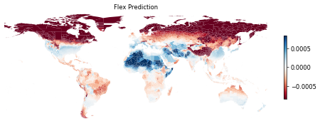

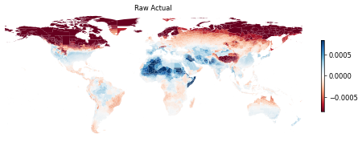

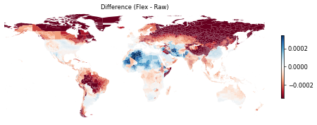

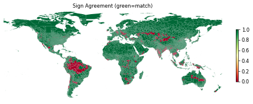

[interactive chart not shown]

Top 5 best predicted Top 5 worst predicted

Year 2099 · T<sub>mean</sub> across these regions: 1.96°C

| Region | Raw | Flex | Residual |
| --- | --- | --- | --- |
| CHN.6.58.346 | -2.54e-5 | -2.54e-5 | -8.70e-10 |
| USA.37.2184 | 1.94e-4 | 1.94e-4 | -9.61e-10 |
| GTM.3.Race4113e9b3a45b8 | -2.38e-4 | -2.38e-4 | 6.84e-9 |
| USA.34.1897 | 1.14e-4 | 1.14e-4 | -2.94e-8 |
| AUS.4.234 | 5.98e-5 | 5.98e-5 | 3.10e-8 |
| CHN.30.315.2167 | -9.78e-4 | -0.00258 | -0.0016 |
| CHN.30.318.2210.Rde47a34c1c843aec | -9.48e-4 | -0.00246 | -0.00151 |
| CHN.30.318.2205 | -9.37e-4 | -0.00244 | -0.00151 |
| CHN.30.315.2170 | -9.66e-4 | -0.00247 | -0.0015 |
| CHN.30.318.2202 | -9.38e-4 | -0.00243 | -0.0015 |

**low**

**Correlation:** 0.9189 | **RMSE:** 0.000187 | **Sign agreement:** 90.9%

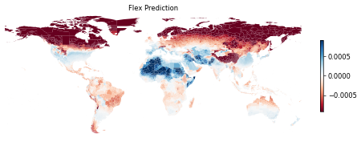

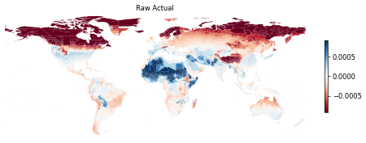

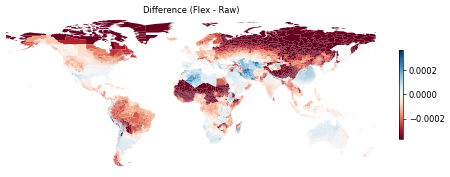

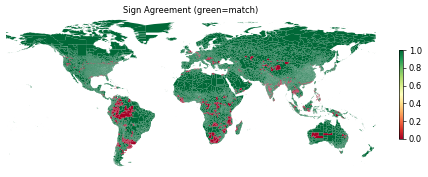

[interactive chart not shown]

Top 5 best predicted Top 5 worst predicted